# Planning by Numbers Final: Safety-as-a-Service

Micah Epstein & Zoe Yoo

4/3/2022

# I. Introduction

## Towards Understanding the Gap Between Reported Traffic Conditions and Actual Traffic Injuries

For our final project, we wanted to examine how and whether 311 cases, and specifically mobility-related 311 cases, could be a useful predictor of a city’s high-injury network. We use Philadelphia as our test city, as there is already a comprehensive high-injury network (HIN) defined and released by the city that we were able to easily analyze. High-injury networks are generally defined as streets that pose higher risk for accidents and injuries to occur, across all modes of transportation. Some cities discern high-injury networks for each mode, such as varying HINs for pedestrian or cyclist injuries, but Philadelphia’s is meant to be comprehensive for all modes. According to the City of Philadelphia’s Vision Zero Action Plan for 2025, 80% of injuries occur on just 12% of city streets; Philadelphia’s high-injury network was formed around data on crash-related injuries and fatalities.

Our original idea for this project was to create a high-injury network for a city that doesn’t have one yet (Pittsburgh), and then compare it to qualitative (311) and demographic data to understand the value of citizen reporting and the injury burden on certain groups. However, we found that both defining and analyzing a HIN for a new city would not be achievable within the time frame, and moved to instead applying the project’s initial idea for 311-related and demographic analysis to Philadelphia’s already-established network.

We seek to build upon existing research on 311 reporting. Significant research has been done on 311 reporting in Boston, using a mixed methods approach that is equal parts social science and anthropology. O’Brien et. al. found that “higher attachment with the space was associated with a greater motivation to enforce local social norms and benefit the broader community.” [1] With this framework in place, the use of mobility-related 311 cases in comparison to actual traffic injuries allowed us to focus in on places not only where reporting is low, but where *reporting does not reflect actual conditions*. We also take a more socioeconomic approach - seeking to connect the fascinating behavioral dynamics studied by O’Brien et. al. and connect it to variables like commute mode, homeownership, and poverty.

We define mobility-related 311 cases as those that relate to street conditions.

```r
df <- tibble(
  mobility = c("Abandoned Vehicle",
                              "Complaint (Streets)",
                              "Dangerous Sidewalk",
                              "Line Striping",
                              "Other (Streets)",
                              "Right of Way Unit",
                              "Right of Way",
                              "Salting",
                              "Stop Sign Repair",
                              "Street Defect",
                              "Street Paving",
                              "Street Trees",
                              "Traffic (Other)",
                              "Traffic Signal Emergency"))


kable(df,
      caption="311 Cases Classified as Mobility Cases")
```

311 Cases Classified as Mobility Cases

| mobility |
| --- |
| Abandoned Vehicle |
| Complaint (Streets) |
| Dangerous Sidewalk |
| Line Striping |
| Other (Streets) |
| Right of Way Unit |
| Right of Way |
| Salting |
| Stop Sign Repair |
| Street Defect |
| Street Paving |
| Street Trees |
| Traffic (Other) |
| Traffic Signal Emergency |

In this study, we explore the correlations between demographic data, 311 cases, and the presence of high-injury networks, and develop predictive models for metrics around these networks.

# II. Data Preparation and Exploratory Analysis

## Data

To examine demographic data, we utilize 2019 American Community Survey 5-Year estimates for census tracts. 311 Data is also pulled from 2019.

```r
#ONLY NEED TO RUN THIS BLOCK IF RE-DOING ACS DATA

get_acs_csv <- function(yr1, variableList, nameList) {

  acs1 <- get_acs(geography = "tract",
                   year = yr1,
                   variables = variableList,
                   geometry = TRUE,
                   state  = "PA",
                   county = "Philadelphia",
                   output = "wide"
  )

  acs_full <- acs1 %>% dplyr:: select(!ends_with("M")) #include this line to remove margins of error
  names(acs_full) <- c("GEOID","NAME", nameList,"geometry")
  #acs_full <- acs_full[order(acs_full$GEOID),]
  #write.csv(acs_full, file=paste(deparse(substitute(variableList)), yr1,"-",yr2, ".csv")) #include this line to export a csv
  return(acs_full)
}

#use this line to look at acs variables
#variables19_5 <- load_variables(year = 2019,dataset = "acs5")


variableList <- c("B01001_001", #total population
              "B01001_002", #total male
              "B01001_026", #total female
              "B02001_002", #white alone
              "B02001_003", #black alone
              "B02001_004", #AmIn/AlNative alone
              "B02001_005", #Asian alone
              "B02001_006", #Native hawaiian/PI alone
              "B02001_007", #some other race alone
              "B02001_008", #two plus races
              "B03003_003", #total Hispanic or Latino
              "B05009_001", #under 18 years B05009_001 for 2010, B09001_001 for 2019
              "B15001_001", #18 years + B15001_001 for 2010, B09021_001 for 2019
              "B11003_001", #families with children under 18
              "B08301_001", #workers
              "B08301_002", #means of transportation to work: car
              "B08301_010", #means of transportation to work: public transit
              "B08301_018", #means of transportation to work: bicycle
              "B08301_019", #means of transportation to work: walked
              "B08301_021", #means of transportation to work: wfh
              "B19013_001", #median income
              "B17001_002", #Income in the past 12 months below poverty level
              "B17001_031", #Income in the past 12 months at or above poverty level
              "B25064_001", #median gross rent
              "B25003_002", #owner occupied
              "B25003_003" #renter occupied
              )

nameList <- c("pop",
                "male",
                "fem",
                "white",
                "black",
                "native_am",
                "asian",
                "nh_pi",
                "other",
                "multi",
                "hisp_lat",
                "Under_18",
                "Above_18",
                "fam_child",
                "workers",
                "Car",
                "Transit",
                "Bicycle",
                "Walking",
                "WFH",
                "mdn_inc",
                "blw_pov",
                "abv_pov",
                "med_rent",
              "own",
              "rent")

acs_data <- get_acs_csv(2019,variableList, nameList)
# add percentages
acs_data <- acs_data %>%
  mutate(PCT_m = male/pop,
         PCT_f = fem/pop,
         PCT_wht = white/pop,
         PCT_blk = black/pop,
         PCT_na = native_am/pop,
         PCT_asn = asian/pop,
         PCT_pi = nh_pi/pop,
         PCT_oth = other/pop,
         PCT_mlt = multi/pop,
         PCT_hsp = hisp_lat/pop,
         PCT_fam = Under_18/pop,
         PCT_car = Car/workers,
         PCT_trn = Transit/workers,
         PCT_bik = Bicycle/workers,
         PCT_wlk = Walking/workers,
         PCT_wfh = WFH/workers,
         PCT_pov = blw_pov/pop,
         PCT_own = own/pop,
         PCT_rent = rent/pop,
         maj_wht = if_else(PCT_wht > 0.50, 1, 0),
         maj_blk = if_else(PCT_blk > 0.50, 1, 0))

acs_data <- st_transform(acs_data,crs=4326)

#this line writes the data to a shapefile
st_write(acs_data,"./data/acs_bg.shp", driver="ESRI Shapefile", append=FALSE)
```

## Spatial Structure

Because we need to combine 311 data, which is point data, ACS data, which is formatted in polygons, and HIN and street data, which is made up of lines (that cross many ACS polygons), we had to consider the best way to integrate both forms. We decided to evaluate HINs through street intersections; to transform the street network into polygons, we created polygons that center at and are equidistant between each intersection. After this, we joined 311 point data to these intersection polygons, then joined ACS data by transferring the data from whichever ACS polygon had the largest overlap to each intersection polygon.

There are a few issues with this structure; for one, the intersections polygons created vary greatly in size due to differing block lengths, especially near parks and the Schuylkill river. We attempted to alleviate this by clipping polygons based on the Schuylkill river. Second, ACS data will not be entirely exact, as there may be differing tracts that overlap each intersection polygon. Despite these concerns, this format is fairly accurate and proved to be easier to work with than other methods of data combination.

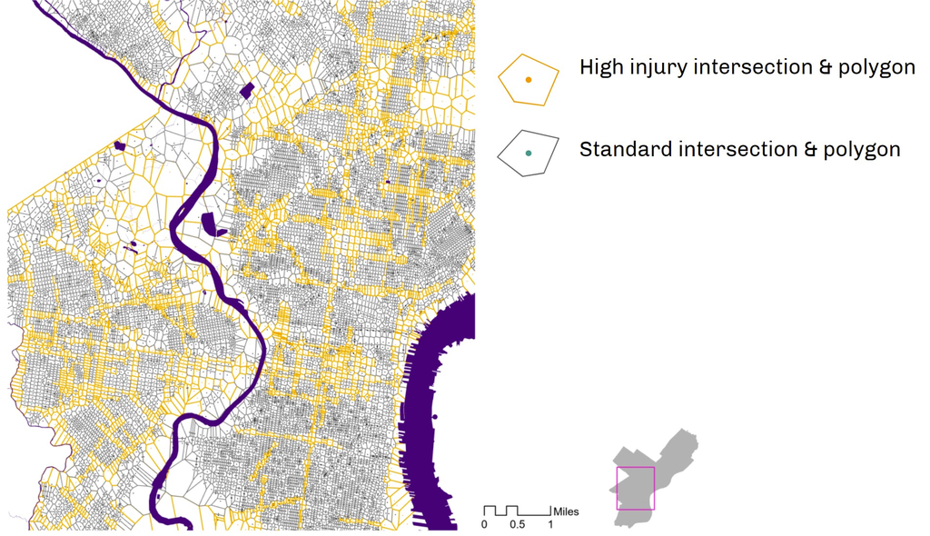

Intersection Polygons

```r
#ONLY NEED TO RUN THIS BLOCK IF RE-DOING ACS DATA

#setwd("G:/My Drive/GrSchool/CPLN 505 Planning by Numbers/PBN_Final")

all311 <- read_sf("./data/311_2019_allSelected.shp")

m311 <- all311 %>% filter(service_na %in%
                            c("Abandoned Vehicle",
                              "Complaint (Streets)",
                              "Dangerous Sidewalk",
                              "Line Striping",
                              "Other (Streets)",
                              "Right of Way Unit",
                              "Right of Way",
                              "Salting",
                              "Stop Sign Repair",
                              "Street Defect",
                              "Street Paving",
                              "Street Trees",
                              "Traffic (Other)",
                              "Traffic Signal Emergency"))

st_write(m311,"./data/m311.shp", driver="Esri Shapefile", append=FALSE)

hin <- read_sf("./data/high_injury_network_2020.shp")
streets <- read_sf("./data/CompleteStreets.shp")
ip <- read_sf("./data/intersection_polygons_clip.shp")

crash <- read_sf("./data/COLLISION_CRASH_2016_2020.shp")
crash_fatal <- crash %>% filter(FATAL_COUN > 0)
crash_injury <- crash %>% filter(INJURY_COU > 0)

ip2 <- ip %>%
  mutate(all311 = lengths(st_intersects(.,all311)),
         m311 = lengths(st_intersects(.,m311)),
         hin_c=lengths(st_intersects(.,hin)),
         hin = if_else(hin_c > 0, 1,0),
         crsh_c=lengths(st_intersects(.,crash)),
         fatal =if_else(lengths(st_intersects(.,crash_fatal)) > 0, 1, 0),
         fatal_c =lengths(st_intersects(.,crash_fatal)),
         inj = if_else(lengths(st_intersects(.,crash_injury)) > 0, 1,0),
         inj_c = lengths(st_intersects(.,crash_injury))
         )
st_write(ip2,"./data/ip.shp", driver="ESRI Shapefile", append=FALSE)

#ip <- st_join(ip,streets,join=st_intersects)
#this line joins polygons to acs data, but takes too long so just do this via spatial join in GIS
#ip <- st_join(ip,acs_data,join=st_intersects, largest=TRUE)

#write.csv(ip_join, file="./data/ip_join.csv")
```

```r
dat <- read_sf("./data/ip_acs_join.shp")

dat <- select(dat, -c(TARGET_FID, Id, Input_FID, OBJECTID, NODE_ID))

dat <- dat %>%
  mutate(lm311 = if_else(m311 < 4, 1, 0),
         logm311 = log(m311),
         gap = if_else(m311<4 & hin==1, 1,0)
         )

dat_bg <- read_sf("./data/ip_acs_join_bg.shp")

dat_bg <- select(dat_bg, -c(TARGET_FID, Id, Input_FID, OBJECTID, NODE_ID))

dat_bg <- dat_bg %>%
  mutate(lm311 = if_else(m311 < 4, 1, 0),
         logm311 = log(m311),
         gap = if_else(m311<4 & hin==1, 1,0)
         )

#only need these if mapping
# hin <- read_sf("https://github.com/zoenyoo/PBN_Final/raw/main/data/hin.geojson")
# streets <- read_sf("https://github.com/zoenyoo/PBN_Final/raw/main/data/CompleteStreets.geojson")
# ip <- read_sf("https://github.com/zoenyoo/PBN_Final/raw/main/data/intersection_polygons_clip.geojson")
# m311 <- read_sf("https://github.com/zoenyoo/PBN_Final/raw/main/data/m311.geojson")

# ggplot() +
#   geom_point(data = m311, aes(x = lon, y = lat), alpha = .05)
#
# ggplot()+
#   geom_sf(data=dat, show.legend = NA, color = palette5[5], size=0.25)
```

## Exploratory Analysis

### Summary Tables of Continuous Variables

```r
dat %>% st_drop_geometry() %>%
    select_if(., is.numeric) %>%
    stargazer(type="html", title="Summary Table of Continuous Variables",
          single.row = TRUE, digits=1)
```

**Summary Table of Continuous Variables**

[output not shown]

```r
dat1 <- dat %>% st_drop_geometry() %>% filter(m311>3 & hin==1) #high mobility cases and in the hin
dat2 <- dat %>% st_drop_geometry() %>% filter(m311<=3 & hin==1) #low mobility cases and in the hin
dat3 <- dat %>% st_drop_geometry() %>% filter(m311>3 & hin==0) #high mobility cases and not in the hin

dat1 %>% summarise(across(where(is.numeric), ~ mean(.x, na.rm = TRUE))) %>% kable(caption="High Mobility Cases in the HIN") %>%
  kable_styling("striped", full_width = F) %>% scroll_box(width = "1000px", height = "150px")
```

High Mobility Cases in the HIN

| Join_Count | all311 | m311 | hin_c | hin | crsh_c | fatal | fatal_c | inj | inj_c | pop | male | fem | white | black | native_am | asian | nh_pi | other | multi | hisp_lat | Under_18 | Above_18 | fam_child | workers | Car | Transit | Bicycle | Walking | WFH | … |
| --- | --- | --- | --- | --- | --- | --- | --- | --- | --- | --- | --- | --- | --- | --- | --- | --- | --- | --- | --- | --- | --- | --- | --- | --- | --- | --- | --- | --- | --- | --- |
| 1.657815 | 9.101669 | 7.756449 | 1.189681 | 1 | 8.08953 | 0.1062215 | 0.1236722 | 0.8710167 | 6.031866 | 4523.993 | 2122.212 | 2401.781 | 1448.404 | 2167.28 | 21.6305 | 309.5083 | 2.830046 | 437.8998 | 136.4408 | 903.3528 | 991.6055 | 3453.4 | 906.2693 | 1822.61 | 1030.714 | 498.3103 | 31.57132 | 150.758 | 73.12747 | … |

```r
dat2 %>% summarise(across(where(is.numeric), ~ mean(.x, na.rm = TRUE))) %>% kable(caption="Low Mobility Cases in the HIN") %>%
  kable_styling("striped", full_width = F) %>% scroll_box(width = "1000px", height = "150px")
```

Low Mobility Cases in the HIN

| Join_Count | all311 | m311 | hin_c | hin | crsh_c | fatal | fatal_c | inj | inj_c | pop | male | fem | white | black | native_am | asian | nh_pi | other | multi | hisp_lat | Under_18 | Above_18 | fam_child | workers | Car | Transit | Bicycle | Walking | WFH | … |
| --- | --- | --- | --- | --- | --- | --- | --- | --- | --- | --- | --- | --- | --- | --- | --- | --- | --- | --- | --- | --- | --- | --- | --- | --- | --- | --- | --- | --- | --- | --- |
| 1.627287 | 1.929196 | 1.18576 | 1.118536 | 1 | 5.61257 | 0.0799523 | 0.089101 | 0.7983294 | 4.129674 | 4403.953 | 2076.395 | 2327.558 | 1530.323 | 1958.685 | 16.83691 | 325.3341 | 2.604216 | 433.2331 | 136.9375 | 880.1348 | 945.8345 | 3383.691 | 880.1714 | 1783.377 | 1041.418 | 455.3874 | 25.32379 | 154.3926 | 71.55847 | … |

```r
dat3 %>% summarise(across(where(is.numeric), ~ mean(.x, na.rm = TRUE))) %>% kable(caption="High Mobility Cases NOT in the HIN") %>%
  kable_styling("striped", full_width = F) %>% scroll_box(width = "1000px", height = "150px")
```

High Mobility Cases NOT in the HIN

| Join_Count | all311 | m311 | hin_c | hin | crsh_c | fatal | fatal_c | inj | inj_c | pop | male | fem | white | black | native_am | asian | nh_pi | other | multi | hisp_lat | Under_18 | Above_18 | fam_child | workers | Car | Transit | Bicycle | Walking | WFH | … |
| --- | --- | --- | --- | --- | --- | --- | --- | --- | --- | --- | --- | --- | --- | --- | --- | --- | --- | --- | --- | --- | --- | --- | --- | --- | --- | --- | --- | --- | --- | --- |
| 1.365113 | 9.036145 | 7.46307 | 0 | 0 | 2.041121 | 0.0065479 | 0.0065479 | 0.5301205 | 1.454165 | 4750.637 | 2259.248 | 2491.389 | 1863.155 | 2092.983 | 17.31456 | 302.2412 | 2.163436 | 321.3965 | 151.3837 | 733.5254 | 1021.575 | 3651.174 | 991.3075 | 2060.079 | 1186.894 | 548.9002 | 52.31823 | 149.572 | 86.87428 | … |

```r
# HIN_dat <- filter(dat, hin == 1)
# mcase_dat <- filter(dat, m311 > 3)
# HIN_d <- density(HIN_dat$PCT_own)
# mcase_d <- density(mcase_dat$PCT_own)
# acs_d <- density(dat$PCT_own, na.rm=TRUE)
# plot(HIN_d, ylim=c(0,7))
# plot(mcase_d, ylim=c(0,7))
# plot(acs_d, ylim=c(0,7))
```

# III. Correlation Tests

```r
numericVars <-
  select_if(dat %>% st_drop_geometry(), is.numeric) %>%
  select(Join_Count, all311, m311, hin, hin_c, crsh_c, fatal, fatal_c, inj, inj_c, pop, starts_with("PCT")) %>%
  na.omit()
```

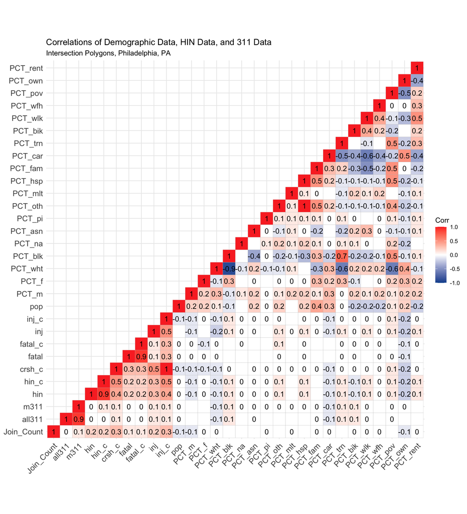

```r
ggcorrplot(  #correlation plot
          round(cor(numericVars), 1),
          p.mat = cor_pmat(numericVars),
          show.diag = TRUE,
          lab = TRUE,
          colors = c("#08519c", "white", "#FA342A"),
          type="lower",
          insig = "blank",
          ) +
          labs(title = "Correlations of Demographic Data, HIN Data, and 311 Data",
               subtitle = "Intersection Polygons, Philadelphia, PA")
```

```r
#backward stepwise regression
hin_test <- glm(hin ~ pop + mdn_inc + med_rent + workers + PCT_f + PCT_wht + maj_wht + PCT_blk + maj_blk + PCT_asn + PCT_na + PCT_pi + PCT_oth + PCT_mlt + PCT_hsp + PCT_car + PCT_trn + PCT_bik + PCT_wlk + PCT_wfh + PCT_own + PCT_pov + PCT_fam + all311 + m311,
            data = dat %>% st_drop_geometry(),
            family="binomial" (link="logit"))

lm311_test <- glm(lm311 ~ pop + mdn_inc + med_rent + workers + PCT_f + PCT_wht + maj_wht + PCT_blk + maj_blk + PCT_asn + PCT_na + PCT_pi + PCT_oth + PCT_mlt + PCT_hsp + PCT_car + PCT_trn + PCT_bik + PCT_wlk + PCT_wfh + PCT_own + PCT_pov + PCT_fam,
            data = dat %>% st_drop_geometry(),
            family="binomial" (link="logit"))

# check this for na values
gap_test <- glm(lm311 ~ pop + mdn_inc + med_rent + workers + PCT_f + PCT_wht + maj_wht + PCT_blk + maj_blk + PCT_asn + PCT_na + PCT_pi + PCT_oth + PCT_mlt + PCT_hsp + PCT_car + PCT_trn + PCT_bik + PCT_wlk + PCT_wfh + PCT_own + PCT_pov + PCT_fam,
            data = dat %>% st_drop_geometry() %>% filter(hin==1),
            family="binomial" (link="logit"))

drop1(hin_test, test="Chisq")
```

```
## Single term deletions
##
## Model:
## hin ~ pop + mdn_inc + med_rent + workers + PCT_f + PCT_wht +
##     maj_wht + PCT_blk + maj_blk + PCT_asn + PCT_na + PCT_pi +
##     PCT_oth + PCT_mlt + PCT_hsp + PCT_car + PCT_trn + PCT_bik +
##     PCT_wlk + PCT_wfh + PCT_own + PCT_pov + PCT_fam + all311 +
##     m311
##          Df Deviance   AIC     LRT  Pr(>Chi)
## <none>         16860 16912
## pop       1    16862 16912   1.738  0.187355
## mdn_inc   1    16866 16916   5.968  0.014566 *
## med_rent  1    16892 16942  32.388 1.263e-08 ***
## workers   1    16860 16910   0.144  0.704068
## PCT_f     1    16865 16915   5.083  0.024168 *
## PCT_wht   1    16860 16910   0.050  0.822303
## maj_wht   1    16860 16910   0.408  0.522956
## PCT_blk   1    16862 16912   1.741  0.186989
## maj_blk   1    16860 16910   0.087  0.768116
## PCT_asn   1    16866 16916   6.309  0.012012 *
## PCT_na    1    16860 16910   0.481  0.487833
## PCT_pi    1    16860 16910   0.487  0.485421
## PCT_oth   1    16877 16927  16.961 3.815e-05 ***
## PCT_mlt   1    16860 16910   0.301  0.583329
## PCT_hsp   1    16861 16911   1.365  0.242691
## PCT_car   1    16863 16913   3.313  0.068716 .
## PCT_trn   1    16863 16913   2.876  0.089918 .
## PCT_bik   1    16891 16941  30.678 3.046e-08 ***
## PCT_wlk   1    16860 16910   0.272  0.602235
## PCT_wfh   1    16867 16917   6.999  0.008157 **
## PCT_own   1    16965 17015 104.899 < 2.2e-16 ***
## PCT_pov   1    16861 16911   0.756  0.384612
## PCT_fam   1    16878 16928  18.159 2.032e-05 ***
## all311    1    16913 16963  52.615 4.059e-13 ***
## m311      1    16937 16987  76.663 < 2.2e-16 ***
## ---
## Signif. codes:  0 '***' 0.001 '**' 0.01 '*' 0.05 '.' 0.1 ' ' 1
```

```r
#step(gap_test, direction="backward")
#step(hin_test, direction="backward")

anova(hin_test, test="Chisq")
```

```
## Analysis of Deviance Table
##
## Model: binomial, link: logit
##
## Response: hin
##
## Terms added sequentially (first to last)
##
##
##          Df Deviance Resid. Df Resid. Dev  Pr(>Chi)
## NULL                     16865      18076
## pop       1    14.82     16864      18061 0.0001181 ***
## mdn_inc   1   338.36     16863      17723 < 2.2e-16 ***
## med_rent  1   154.50     16862      17568 < 2.2e-16 ***
## workers   1    14.05     16861      17554 0.0001785 ***
## PCT_f     1    17.37     16860      17537 3.076e-05 ***
## PCT_wht   1    63.15     16859      17474 1.915e-15 ***
## maj_wht   1    15.89     16858      17458 6.728e-05 ***
## PCT_blk   1   215.96     16857      17242 < 2.2e-16 ***
## maj_blk   1     4.85     16856      17237 0.0276612 *
## PCT_asn   1     0.55     16855      17237 0.4587719
## PCT_na    1     0.00     16854      17237 0.9602461
## PCT_pi    1     0.01     16853      17237 0.9242424
## PCT_oth   1    11.36     16852      17225 0.0007515 ***
## PCT_mlt   1    14.16     16851      17211 0.0001676 ***
## PCT_hsp   1     3.32     16850      17208 0.0682871 .
## PCT_car   1    30.77     16849      17177 2.899e-08 ***
## PCT_trn   1    14.58     16848      17162 0.0001341 ***
## PCT_bik   1    63.87     16847      17098 1.327e-15 ***
## PCT_wlk   1    25.58     16846      17073 4.252e-07 ***
## PCT_wfh   1     3.08     16845      17070 0.0793406 .
## PCT_own   1   104.29     16844      16966 < 2.2e-16 ***
## PCT_pov   1     4.00     16843      16962 0.0453982 *
## PCT_fam   1    17.94     16842      16944 2.284e-05 ***
## all311    1     6.97     16841      16937 0.0082880 **
## m311      1    76.66     16840      16860 < 2.2e-16 ***
## ---
## Signif. codes:  0 '***' 0.001 '**' 0.01 '*' 0.05 '.' 0.1 ' ' 1
```

# IV. Binary & Multinomial? Logit

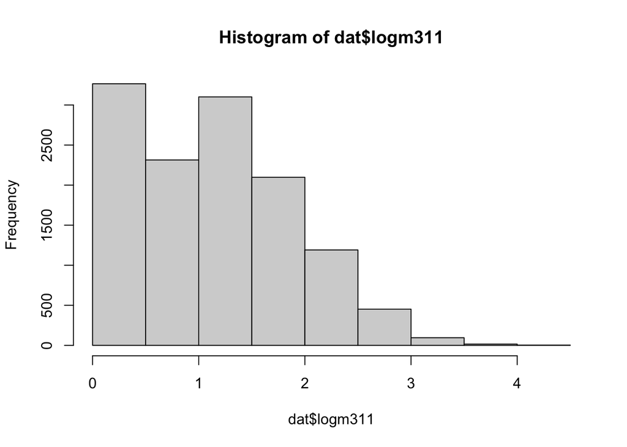

```r
hist(dat$logm311)
```

## High Injury Networks

```r
#our honed model
hinMod1 <- glm(hin ~ med_rent + maj_blk + PCT_car + PCT_bik + PCT_own + m311,
               data=dat %>% st_drop_geometry(),
               family="binomial" (link="logit"))

#model based on backwards stepwise
hinMod2 <- glm(hin ~ mdn_inc + med_rent + PCT_f + PCT_blk + PCT_asn +
    PCT_oth + PCT_hsp + PCT_car + PCT_trn + PCT_bik + PCT_wfh +
    PCT_own + PCT_fam + all311 + m311,
               data=dat %>% st_drop_geometry(),
               family="binomial" (link="logit"))

#model just using crash and injury/fatal data
hinMod3 <- glm(hin ~ crsh_c + inj_c + fatal_c,
               data=dat %>% st_drop_geometry(),
               family="binomial" (link="logit"))

hinModb <- glm(hin ~ crsh_c + inj_c + fatal_c,
               data=dat_bg %>% st_drop_geometry(),
               family="binomial" (link="logit"))

stargazer(hinMod1, hinMod2, hinMod3,
          type="html", title="High-Injury Network Intersections",
          column.labels = c("Model 1", "Model 2"),
          single.row = TRUE, digits=2)
```

**High-Injury Network Intersections**

|  | *Dependent variable:* |  |  |
| --- | --- | --- | --- |
|  | hin |  |  |
|  | Model 1 | Model 2 |  |
|  | (1) | (2) | (3) |
| mdn_inc |  | -0.0000** (0.0000) |  |
| med_rent | 0.0002*** (0.0001) | 0.001*** (0.0001) |  |
| maj_blk | 0.11*** (0.04) |  |  |
| PCT_f |  | 0.90** (0.37) |  |
| PCT_blk |  | 1.06*** (0.12) |  |
| PCT_asn |  | 2.03*** (0.29) |  |
| PCT_oth |  | 4.62*** (0.60) |  |
| PCT_hsp |  | -0.62* (0.36) |  |
| PCT_car | -0.43*** (0.13) | -1.38*** (0.21) |  |
| PCT_trn |  | -1.31*** (0.28) |  |
| PCT_bik | -6.76*** (0.77) | -6.64*** (0.81) |  |
| PCT_wfh |  | -2.91*** (0.67) |  |
| PCT_own | -6.22*** (0.32) | -3.95*** (0.37) |  |
| PCT_fam |  | -2.02*** (0.35) |  |
| all311 |  | -0.09*** (0.01) |  |
| m311 | 0.03*** (0.004) | 0.12*** (0.01) |  |
| crsh_c |  |  | 0.15*** (0.02) |
| inj_c |  |  | 0.12*** (0.03) |
| fatal_c |  |  | 1.57*** (0.14) |
| Constant | -0.05 (0.10) | -0.37*** (0.14) | -1.97*** (0.03) |
| Observations | 16,866 | 16,866 | 16,866 |
| Log Likelihood | -8,643.19 | -8,435.43 | -7,487.66 |
| Akaike Inf. Crit. | 17,300.38 | 16,902.86 | 14,983.32 |
| *Note:* | p<0.1; p<0.05; p<0.01 |  |  |

```r
data.frame(100*(exp(coef(hinMod1)))-1) %>%
  kable()
```

|  | X100….exp.coef.hinMod1……1 |
| --- | --- |
| (Intercept) | 94.5429368 |
| med_rent | 99.0235609 |
| maj_blk | 110.7776230 |
| PCT_car | 64.2446404 |
| PCT_bik | -0.8844418 |
| PCT_own | -0.8009256 |
| m311 | 101.6840253 |

## Low Reporting of Mobility Cases

These models predict for intersections that have mobility case reporting of 3 or fewer.

```r
# our honed model
l311Mod1 <- glm(lm311 ~ med_rent + maj_blk + PCT_car + PCT_bik + PCT_own + PCT_pov,
               data=dat %>% st_drop_geometry(),
               family="binomial" (link="logit"))


l311Modb <- glm(lm311 ~ med_rent + maj_blk + PCT_car + PCT_bik + PCT_own + PCT_pov,
               data=dat_bg %>% st_drop_geometry(),
               family="binomial" (link="logit"))
#model based on backwards stepwise
l311Mod2 <- glm(formula = lm311 ~ mdn_inc + med_rent + workers + PCT_f +
    PCT_blk + maj_blk + PCT_hsp + PCT_trn + PCT_bik + PCT_wlk +
    PCT_wfh + PCT_own + PCT_pov + PCT_fam, family = binomial(link = "logit"),
    data = dat %>% st_drop_geometry())

stargazer(l311Mod1, l311Mod2,
          type="html", title="Low Mobility Case-Reporting Intersections",
          column.labels = c("Model 1", "Model 2"),
          single.row = TRUE, digits=2)
```

**Low Mobility Case-Reporting Intersections**

|  | *Dependent variable:* |  |
| --- | --- | --- |
|  | lm311 |  |
|  | Model 1 | Model 2 |
|  | (1) | (2) |
| mdn_inc |  | 0.0000*** (0.0000) |
| med_rent | -0.0002*** (0.0001) | -0.0004*** (0.0001) |
| workers |  | -0.0002*** (0.0000) |
| PCT_f |  | 1.99*** (0.34) |
| PCT_blk |  | -1.00*** (0.15) |
| maj_blk | -0.23*** (0.04) | 0.22** (0.10) |
| PCT_car | 0.61*** (0.12) |  |
| PCT_hsp |  | -0.86*** (0.14) |
| PCT_trn |  | -1.54*** (0.19) |
| PCT_bik | -2.30*** (0.57) | -4.43*** (0.58) |
| PCT_wlk |  | -0.47* (0.26) |
| PCT_wfh |  | -1.24** (0.56) |
| PCT_own | -0.90*** (0.30) | -0.55 (0.34) |
| PCT_pov | -0.84*** (0.15) | 1.14*** (0.25) |
| PCT_fam |  | -1.72*** (0.34) |
| Constant | 1.21*** (0.12) | 1.53*** (0.15) |
| Observations | 16,866 | 16,866 |
| Log Likelihood | -10,269.11 | -10,135.47 |
| Akaike Inf. Crit. | 20,552.21 | 20,300.93 |
| *Note:* | p<0.1; p<0.05; p<0.01 |  |

```r
data.frame(100*(exp(coef(l311Mod1)))-1) %>%
  kable()
```

|  | X100….exp.coef.l311Mod1……1 |
| --- | --- |
| (Intercept) | 335.232596 |
| med_rent | 98.979345 |
| maj_blk | 78.360239 |
| PCT_car | 183.300971 |
| PCT_bik | 8.996052 |
| PCT_own | 39.615710 |
| PCT_pov | 42.171354 |

## “Gap” Intersections: Low Mobility-Related 311 Reporting and HIN

```r
gap_dat <- filter(dat, hin == 1)

gap_dat$gap <- 0
gap_dat$gap[gap_dat$m311 <= 3 ] <- 1
```

The variables that I think might predict gaps in reporting are as follows:  
1. Majority Black binary (maj_blk)  
2. Percent of homeowners (PCT_own)  
3. Percent drive to work (PCT_car)  
4. Percent below poverty line (PCT_pov)

Before we create a model with these variables, we look for multicollinearity using a correlation chart. To do this we create a dataset with only those variables (as well as the dependent gap variable).

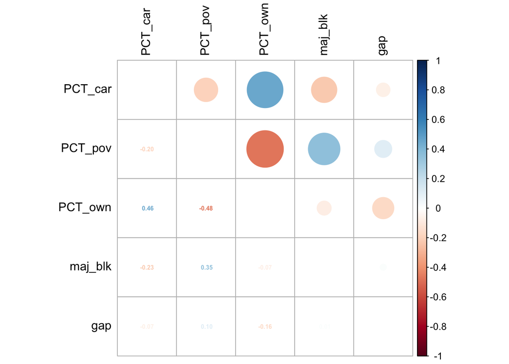

```r
varsKeep <- c("gap","maj_blk" , "PCT_own", "PCT_car","PCT_pov")
corr_dat<-dat[ , which(names(dat) %in% varsKeep)]

corr_dat <- select_if(corr_dat %>% st_drop_geometry(), is.numeric)

M = cor(corr_dat)
corrplot.mixed(M, tl.pos = 'lt', tl.col = 'black', assign.col = "black", number.cex = 0.5)
```

There is some correlation between percent poverty and percent homeowner, as well as between percent drive to work and percent homeowner but it is not large enough (>0.5) to consider dropping either variable.

Now we will use a backwards step method to arrive at the leanest model from this initial set of independent variables.

```r
step ( glm ( gap ~ PCT_car + PCT_pov + PCT_own + maj_blk, data=dat, family = binomial), direction = "backward")
```

```
## Start:  AIC=13747.42
## gap ~ PCT_car + PCT_pov + PCT_own + maj_blk
##
##           Df Deviance   AIC
## - maj_blk  1    13737 13745
## <none>          13737 13747
## - PCT_car  1    13740 13748
## - PCT_pov  1    13759 13767
## - PCT_own  1    13972 13980
##
## Step:  AIC=13745.43
## gap ~ PCT_car + PCT_pov + PCT_own
##
##           Df Deviance   AIC
## <none>          13737 13745
## - PCT_car  1    13740 13746
## - PCT_pov  1    13762 13768
## - PCT_own  1    13986 13992
```

```
##
## Call:  glm(formula = gap ~ PCT_car + PCT_pov + PCT_own, family = binomial,
##     data = dat)
##
## Coefficients:
## (Intercept)      PCT_car      PCT_pov      PCT_own
##     -0.9268       0.2152       0.7733      -5.9556
##
## Degrees of Freedom: 16865 Total (i.e. Null);  16862 Residual
## Null Deviance:       14200
## Residual Deviance: 13740     AIC: 13750
```

```r
gap_mod <- glm(formula = gap ~ PCT_car + PCT_pov + PCT_own, family = binomial,
    data = dat)

summary(gap_mod)
```

```
##
## Call:
## glm(formula = gap ~ PCT_car + PCT_pov + PCT_own, family = binomial,
##     data = dat)
##
## Deviance Residuals:
##     Min       1Q   Median       3Q      Max
## -0.9823  -0.6180  -0.5057  -0.4021   2.5644
##
## Coefficients:
##             Estimate Std. Error z value Pr(>|z|)
## (Intercept) -0.92677    0.09254 -10.015  < 2e-16 ***
## PCT_car      0.21521    0.12945   1.663   0.0964 .
## PCT_pov      0.77334    0.15777   4.902 9.49e-07 ***
## PCT_own     -5.95559    0.37930 -15.701  < 2e-16 ***
## ---
## Signif. codes:  0 '***' 0.001 '**' 0.01 '*' 0.05 '.' 0.1 ' ' 1
##
## (Dispersion parameter for binomial family taken to be 1)
##
##     Null deviance: 14204  on 16865  degrees of freedom
## Residual deviance: 13737  on 16862  degrees of freedom
## AIC: 13745
##
## Number of Fisher Scoring iterations: 4
```

```r
pred <- as.data.frame(fitted(gap_mod))
pred <- rename(pred, "prob" = "fitted(gap_mod)")
pred <- mutate(pred, "binary" = ifelse(prob < 0.5, 0, 1))
dat$gap_binary <- pred$binary

SuccesfulPredictions <-sum(dat$gap == 1 & dat$gap_binary == 1)
AccuracyRate <- (sum(dat$gap == 1 & dat$gap_binary == 1) + sum(dat$gap == 0 & dat$gap_binary == 0)) / nrow(dat)
SuccesfulPredictions
```

```
## [1] 0
```

```r
AccuracyRate
```

```
## [1] 0.8509427
```

We get an accuracy rate of 85%, which is okay (not bad, but not great), but it is important to note that this model is not able to successfully predict any gap intersections. We can still interpret the coefficients, but there is still significant room for improvement in this model.

### Interpreting gap coefficients

```r
100 * (exp(coef(gap_mod))-1)
```

```
## (Intercept)     PCT_car     PCT_pov     PCT_own
##   -60.41691    24.01208   116.69953   -99.74087
```

```r
gapMod1 <- glm(lm311 ~ maj_blk + PCT_bik + PCT_own,
               data=dat %>% st_drop_geometry() %>% filter(hin==1),
               family="binomial" (link="logit"))
summary(gapMod1)
```

Call: glm(formula = lm311 ~ maj_blk + PCT_bik + PCT_own, family = binomial(link = “logit”), data = dat %>% st_drop_geometry() %>% filter(hin == 1))

Deviance Residuals: Min 1Q Median 3Q Max  
-1.6029 -1.4057 0.8665 0.9392 1.2003

(Dispersion parameter for binomial family taken to be 1)

```
Null deviance: 4932.7  on 3831  degrees of freedom
```

Residual deviance: 4911.2 on 3828 degrees of freedom AIC: 4919.2

Number of Fisher Scoring iterations: 4

```r
gapMod2 <- glm(formula = lm311 ~ pop + mdn_inc + med_rent + PCT_blk + maj_blk + PCT_na +
    PCT_pi + PCT_oth + PCT_hsp + PCT_car + PCT_bik + PCT_own +
    PCT_pov + PCT_fam, family = binomial(link = "logit"),
    data = dat %>% st_drop_geometry() %>% filter(hin==1))

stargazer(gapMod1,
          type="html", title="Gap Intersections",
          column.labels = c("Model 1", "Model 2"),
          single.row = TRUE, digits=2)
```

**Gap Intersections**

|  | *Dependent variable:* |
| --- | --- |
|  | lm311 |
|  | Model 1 |
| maj_blk | -0.23*** (0.07) |
| PCT_bik | -3.07** (1.21) |
| PCT_own | -0.94** (0.48) |
| Constant | 0.96*** (0.10) |
| Observations | 3,832 |
| Log Likelihood | -2,455.62 |
| Akaike Inf. Crit. | 4,919.25 |
| *Note:* | p<0.1; p<0.05; p<0.01 |

```r
data.frame(100*(exp(coef(gapMod1)))-1) %>%
  kable()
```

|  | X100….exp.coef.gapMod1……1 |
| --- | --- |
| (Intercept) | 260.334923 |
| maj_blk | 78.058710 |
| PCT_bik | 3.622666 |
| PCT_own | 38.018077 |

```r
# logm311Mod1 <- glm(logm311 ~ ,
#                data=dat %>% st_drop_geometry(),
#                family="binomial" (link="logit"))
```

# V. Conclusion

These are striking results, and have interesting implications in relationship to existing literature on 311 reporting. O’Brien et. al., using a mixed methods approach, say that “this paints a picture of custodianship, at least as measured through CRM (311) reports, as a pro-social act intended to provide benefit to oneself and others” and that “The effectiveness of the CRM (311) system in promoting neighborhood maintenance may rely primarily on goodwill for the neighborhood”. [O’Brien] With this in mind, we see a negative association between driving to commute, and poverty rates, on pro-social behaviors like custodianship and neighborhood goodwill, as well as a positive association between home ownership and these behaviors. There is already a wealth of research proving the benefits of home ownership [Coulson] and the negative implications of driving [Conkle], while the negative implications of poverty are intuitive. However, in utilizing 311 data and ACS data, we can begin to understand the relationship between civic participation and more closely studied factors such as commute mode choice, housing, and poverty.

Of course, as mentioned above, this model has significant room for improvement. The selected variables and size of data resulted in a model that was not able to succesfully predict a single gap. Conducting this analysis at a broader scale (across multiple cities, perhaps) would likely improve the model. There are also complex social considerations at play. O’Brien et. al. also found that “those who perceived their neighborhood as more cohesive in fact reported fewer public issues.” suggesting that cohesion (perhaps using regularity of block parties, if that data is available, or comparing new residents to long-time residents) should be accounted for and could add significant nuance to the analysis.

## Sources

City of Philadelphia. (2022a). OpenDataPhilly. OpenDataPhilly. https://www.opendataphilly.org/.

City of Philadelphia. (2022b). Vision Zero Philadelphia. Vision Zero. http://visionzerophl.com/.

Conkle, Ann, and Catherine West. “Psychology on the Road.” APS Observer 21, no. 6 (2008).

Coulson, N. Edward, and Herman Li. “Measuring the external benefits of homeownership.” Journal of Urban Economics 77 (2013): 57-67.

O’Brien, D. T. (2018). The urban commons: How data and technology can rebuild our communities. Harvard University Press.

O’Brien, D. T., Gordon, E., & Baldwin, J. (2014). Caring about the community, counteracting disorder: 311 reports of public issues as expressions of territoriality. Journal of Environmental Psychology, 40, 320–330. https://doi.org/10.1016/j.jenvp.2014.08.003.

Pennsylvania Department of Transportation. (2022). Pennsylvania Crash Information Tool. Pennsylvania Department of Transportation. https://crashinfo.penndot.gov/PCIT/welcome.html.

U.S. Census Bureau. (2010-2019). American Community Survey 5-year Estimates.